# Correlación lineal de Pearson

Agustín Castro

2023-10-19

### Pildoras_R. Material de formación

[mi_blog] https://agustincastro.es

Librerías utilizadas.

```r
library(tidyverse)
library(PerformanceAnalytics)
library(apaTables)
library(psych)
library(corrr)
library(corrplot)
library(palmerpenguins)
```

¿Qué son las correlaciones entre variables? ¿Cómo entenderlas y trabajar con ellas? ¿Qué información nos ofrecen? ¿Cómo calcular éstas en R? **En esta entrada trato el tema de la correlación, concretamente la lineal, de Pearson**. Vamos a ver unos cuantos ejemplos utilizando funciones específicas de distintas librerías. En entradas posteriores veremos otros ejemplos de cálculo de correlaciones no paramétricas, como la de Spearman, o Kendall (consideradas ambas coeficientes de correlación de rango).

### Correlación

Para examinar si existe relación entre dos variables aleatorias estudiamos la existencia de **correlación**. Las relaciones entre variables pueden ser diversas y, en la correlación lineal, medimos concretamente la intensidad de la fuerza de la relación lineal entre ambas. Cuando los valores de una variable aumentan con los de otra, hablamos de la existencia de **correlación positiva**, o **directa**. Por el contrario, si el aumento de una variable resulta en la disminución de la otra, estaríamos ante una **correlación negativa**, o **inversa**.

Existen coeficientes de correlación **paramétricos** y **no paramétricos**. El que usemos unos u otros va a depender de que se cumplan, o no, una serie de supuestos en nuestros datos, siendo los paramétricos los más restrictivos en lo que al cumplimiento de estos requisitos se refiere. En este sentido, es importante entender que **no podemos utilizar cualquier test, o coeficiente, en cualquier situación**. Hay que entender bien cuando estos ofrecerían resultados válidos o, por el contrario, conclusiones erróneas. *Es más habitual de lo que parece ver conclusiones basadas en resultados de unos análisis dudosos en cuanto a su planteamiento inicial, y desarrollo*.

**EL COEFICIENTE DE CORRELACIÓN LINEAL DE PEARSON**

El **coeficiente de correlación de PEARSON (r)** es el más utilizado dentro de los coeficientes paramétricos. Por otro lado, dentro de los no paramétricos tenemos los de correlación por rangos de **SPEARMAN** y **KENDALL** (también conocido como Tau de Kendall).

El coeficiente de correlación de Pearson es una prueba que tiene la finalidad de **medir la relación LINEAL entre dos variables continuas**. Este detalle es muy importante porque si la relación entre los elementos no es lineal, el coeficiente no representará verazmente esta relación. *Y es que, atención, dos variables pueden estar correlacionadas, y estarlo de una forma no lineal*.

El coeficiente de Pearson **mide el grado de aproximación de los puntos a lo que sería una recta que representaría la correlación máxima** pero, ¿Qué ocurre si los puntos adoptan una posición dibujando una curva? En estos casos habría que utilizar otro tipo de procedimientos, en los que calcularíamos lo que conocemos como **índices de razón de correlación**. En un gráfico en el que los puntos parecen seguir los trazos de una curva, el posible ajuste no sería linea. Si calculáramos el coeficiente de Pearson nos daría, claro está, un valor bajo. Sin embargo, si podría existir un ajuste significativo de los datos (puntos) a la curva.

El coeficiente de correlación de Pearson puede tomar un rango de valores de **-1 a +1**. Estos valores extremos implicarían la existencia de una **correlación perfecta** (ajuste perfecto a la recta), algo que, por otro lado, es bastante raro en ciencias más allá de la física.

**Aquí un ejemplo sencillo, basado en datos reales**.

Estudiamos si existe relación entre las cantidades de arsénico y nitratos medidos en muestras de lluvia ácida (datos publicados en «The atmospheric Deposition of Arsenic and Association with Acid Precipitation» Atmospheric Environ. (1988): 937-943

```r
nitrato <- c(11, 13, 18, 30, 36, 40, 50, 58, 67, 82, 91, 102)
arsenico <- c(1.1, 0.5, 2.4, 1.2, 2.1, 1.2, 4.0, 2.3, 1.7, 3.7, 3.0, 3.9)

summary(nitrato)
```

```
##    Min. 1st Qu.  Median    Mean 3rd Qu.    Max.
##   11.00   27.00   45.00   49.83   70.75  102.00
```

```r
summary(arsenico)
```

```
##    Min. 1st Qu.  Median    Mean 3rd Qu.    Max.
##   0.500   1.200   2.200   2.258   3.175   4.000
```

Las correlación entre las variables nitrato y arsénico se pueden calcular con la función **cor** y, un test detallado de su cálculo, con la función **cor.test**. Gráficamente podemos representar la relación entre las variables con **pairs** o, con los datos ya en un data frame, con la función **chart.Correlation** de la librería de PerformanceAnalytics.

```r
correlacion <- cor(nitrato, arsenico)
cor(arsenico, nitrato) #exactamente lo mismo, de una u otra forma
```

```
## [1] 0.7319313
```

Hacemos este test para conocer si hay significación estadística en el valor de r (correlación de PEARSON). El p-valor indica la probabilidad de obtener una correlación igual o más extrema que la observada en tus datos si la verdadera correlación entre nitrato y arsénico fuera igual a cero. Este p-valor se compara con el nivel de significación típico de 0.05 (o alfa), el umbral más comúnmente utilizado (es posible usar también el 0.01). **Podemos concluir que la correlación entre nitrato y arsénico es significativa**. La hipótesis nula en este test plantea que la correlación entre las variables es igual a 0, es decir, que no existe.

```r
cor.test(nitrato, arsenico)
```

```
##
##  Pearson's product-moment correlation
##
## data:  nitrato and arsenico
## t = 3.3969, df = 10, p-value = 0.006807
## alternative hypothesis: true correlation is not equal to 0
## 95 percent confidence interval:
##  0.2724915 0.9195640
## sample estimates:
##       cor
## 0.7319313
```

Gráficamente, utilizando las funciones mencionadas anteriormente:

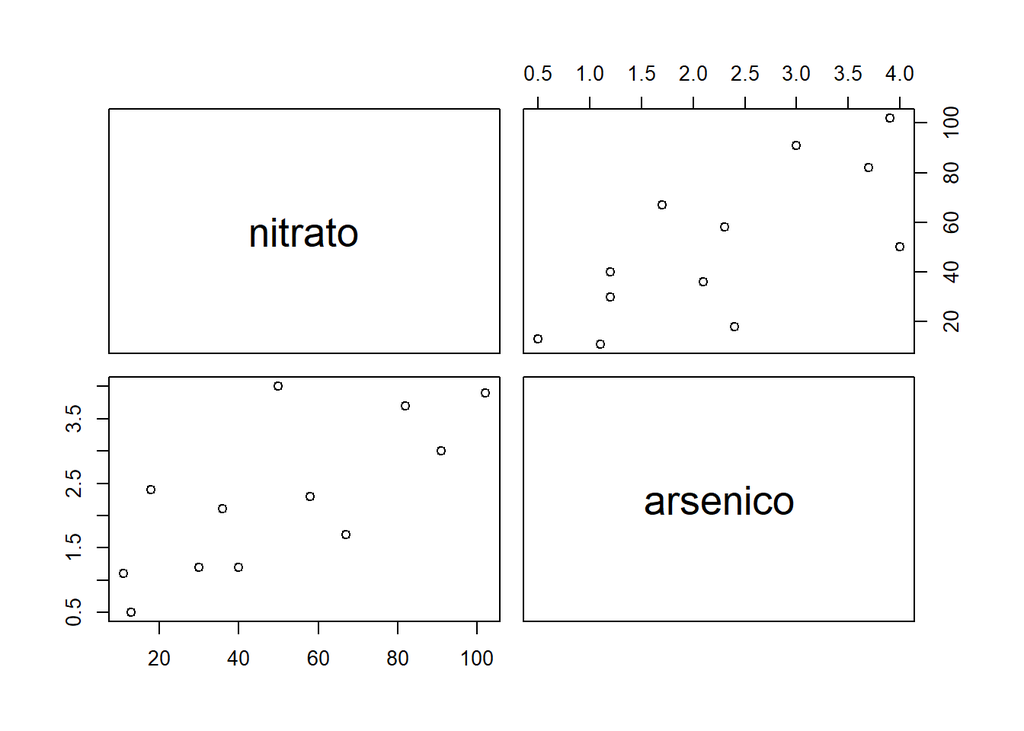

```r
pairs(nitrato ~ arsenico)
```

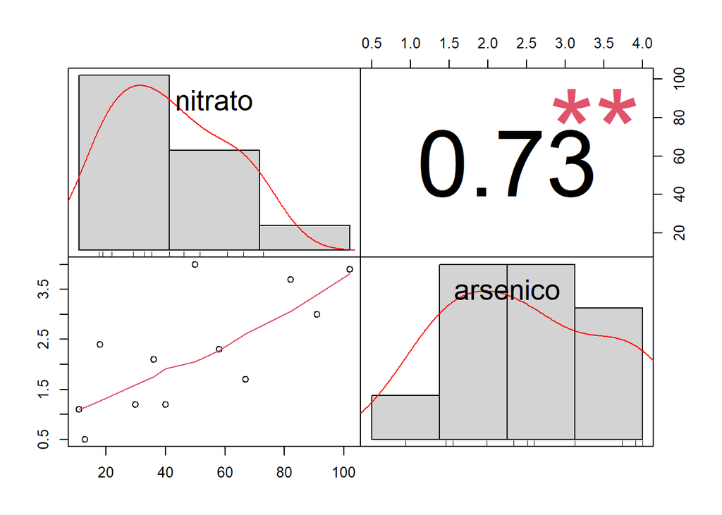

```r
data <- data.frame(nitrato, arsenico)
chart.Correlation(data)
```

Para saber si realmente sería correcto calcular un coeficiente de correlación de Pearson es necesario asegurarnos de que las variables tienen una distribución normal, para lo que utilizaremos el **test de SHAPIRO WILK**.

En una prueba de Shapiro-Wilk la hipótesis nula (H0) es que **los datos siguen una distribución normal**, expresado más correctamente “no hay evidencia suficiente para concluir que los datos no siguen una distribución normal”. La hipótesis alternativa (H1) sería que los datos no siguen una distribución normal.

Si el p-value (p-valor en castellano) es menor que un nivel de significancia predefinido (generalmente 0.05 o 0.01), se rechaza la hipótesis nula. Así, si el p-value es muy pequeño, se concluye que hay evidencia suficiente para afirmar que los datos no siguen una distribución normal.

```r
shapiro.test(nitrato)
```

```
##
##  Shapiro-Wilk normality test
##
## data:  nitrato
## W = 0.94465, p-value = 0.5605
```

```r
shapiro.test(arsenico)
```

```
##
##  Shapiro-Wilk normality test
##
## data:  arsenico
## W = 0.93354, p-value = 0.4191
```

**Cálculo del coeficiente de determinación**

```r
correlacion ^ 2 * 100
```

```
## [1] 53.57234
```

Trabajando con la librería de **Palmer Penguins**. La librería «palmerpenguins» es una librería de datos en R que contiene información biométrica sobre pingüinos. Si, has leído bien. Esta librería es útil para fines educativos y de práctica en análisis de datos y visualización en R, por lo que es conocida por mucha gente. Proporciona **datos biométricos sobre diferentes especies de pingüinos**, incluyendo su tamaño, peso y otras características (por ejemplo, longitud del pico).

Miramos los data que hay en la librería y cargamos el dataset que se llama penguins. Como vamos a hacer ahora una matriz de correlación, sobran todas las columnas que tienen variables no numéricas (eliminamos las columnas 1, 2 y 7, que se refieren a los nombres de las especies «species», nombres de las islas en las que se encuentran «island» y, el sexo de los animales «sex». Así, creamos un nuevo dataset (se llama en R, data frame) al que le ponemos el nombre de df_noNA y que está formado por los casos completos (que no tengan NA). Por último, creamos la matriz de correlación con la función cor.

**¿Que son estos NA?** En el contexto de la gestión de datos, «NA» significa «Not Available» o, «Not Applicable«, y se utiliza para **representar valores faltantes o ausentes en un conjunto de datos**. En una buena parte de análisis se hace necesario «eliminar» previamente estos.

```r
data(package = "palmerpenguins")
data(penguins)
colnames(penguins)
```

```
## [1] "species"           "island"            "bill_length_mm"
## [4] "bill_depth_mm"     "flipper_length_mm" "body_mass_g"
## [7] "sex"               "year"
```

```r
df <- penguins[, -c(1, 2, 7)]
df_noNA <- df[complete.cases(df), ]

matrix_cor <- cor(df_noNA, method = "pearson")
matrix_cor_tres_decimales <- round(matrix_cor, digits = 3)

matrix_cor_tres_decimales
```

```
##                   bill_length_mm bill_depth_mm flipper_length_mm body_mass_g
## bill_length_mm             1.000        -0.235             0.656       0.595
## bill_depth_mm             -0.235         1.000            -0.584      -0.472
## flipper_length_mm          0.656        -0.584             1.000       0.871
## body_mass_g                0.595        -0.472             0.871       1.000
## year                       0.055        -0.060             0.170       0.042
##                     year
## bill_length_mm     0.055
## bill_depth_mm     -0.060
## flipper_length_mm  0.170
## body_mass_g        0.042
## year               1.000
```

Utilizando la librería **apaTables** para crear una tabla de correlaciones en detalle. Esta función **apa.cor.table** permite crear automáticamente una tabla de correlaciones entre las variables y, grabarla en un documento .doc, ahorrándonos un montón de tiempo.

```r
apa.cor.table(df_noNA, filename = "prueba.doc", table.number = 1,
              show.conf.interval = TRUE, landscape = TRUE)
```

```
##
##
## Table 1
##
## Means, standard deviations, and correlations with confidence intervals
##
##
##   Variable             M       SD     1            2            3
##   1. bill_length_mm    43.92   5.46
##
##   2. bill_depth_mm     17.15   1.97   -.24**
##                                       [-.33, -.13]
##
##   3. flipper_length_mm 200.92  14.06  .66**        -.58**
##                                       [.59, .71]   [-.65, -.51]
##
##   4. body_mass_g       4201.75 801.95 .60**        -.47**       .87**
##                                       [.52, .66]   [-.55, -.39] [.84, .89]
##
##   5. year              2008.03 0.82   .05          -.06         .17**
##                                       [-.05, .16]  [-.17, .05]  [.06, .27]
##
##   4
##
##
##
##
##
##
##
##
##
##
##
##   .04
##   [-.06, .15]
##
##
## Note. M and SD are used to represent mean and standard deviation, respectively.
## Values in square brackets indicate the 95% confidence interval.
## The confidence interval is a plausible range of population correlations
## that could have caused the sample correlation (Cumming, 2014).
##  * indicates p < .05. ** indicates p < .01.
##
```

También, de la librería **psych** podemos utilizar la función **pairs.panels** para crear este tipo de gráficos en el que se resumen las correlaciones entre las variables, se indican si son significativas, se muestran sus distribuciones, etc.

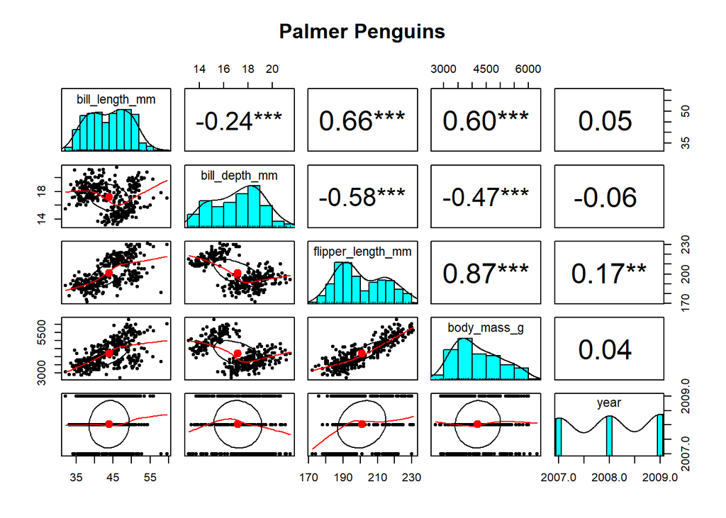

```r
pairs.panels(df_noNA, pch = 20, stars = TRUE, main = "Palmer Penguins")
```

**Algunos gráficos, algo más extraños …**

Podemos crear una red de correlaciones con la funciones **correlate** & **network plot** de la librería **corrr**, con la que podemos ver las relaciones que hay entre unas variables y otras (en rojo las relaciones negativas y en azul las positivas)

```
## Correlation computed with
## • Method: 'pearson'
## • Missing treated using: 'pairwise.complete.obs'
```

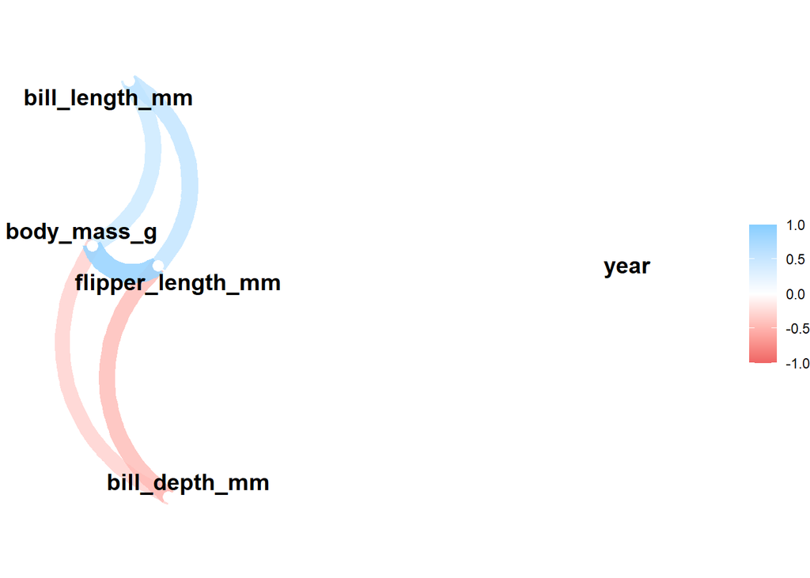

```r
df_noNA %>%
  correlate() %>%
  network_plot()
```

Otro ejemplo. Dibujar una matriz de correlación con la función **corrplot** en la que se muestran las correlaciones positivas en color azul, con un círculo de tamaño mayor conforme más grande es la correlación. En rojo, las correlaciones negativas.

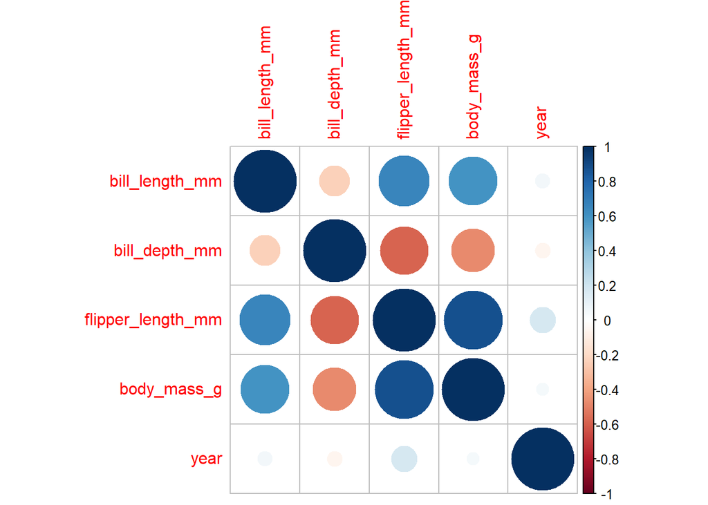

```r
corrplot(matrix_cor_tres_decimales)
```

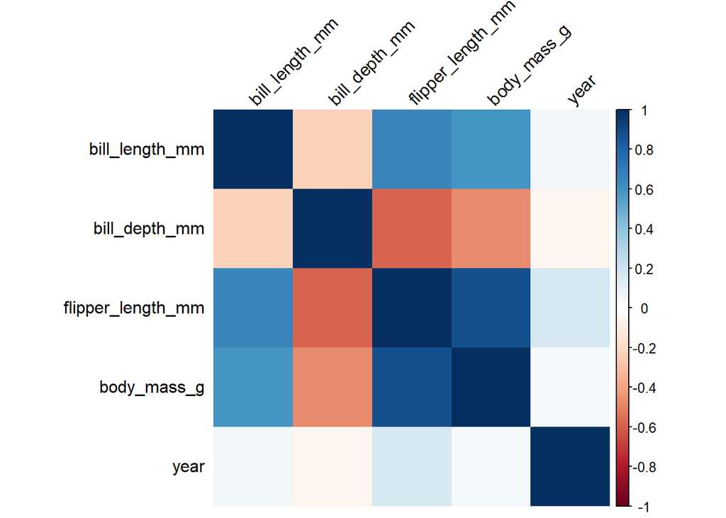

```r
corrplot(matrix_cor_tres_decimales, method = "shade", shade.col = NA,
         tl.col = "black", tl.srt = 45)
```

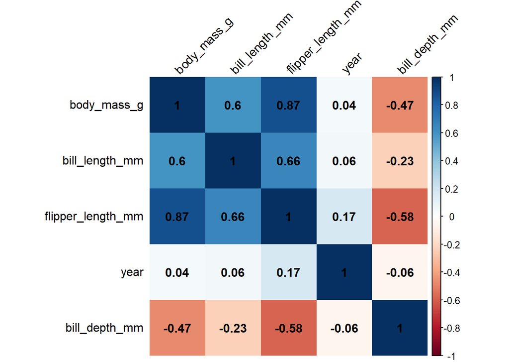

```r
corrplot(matrix_cor_tres_decimales,
         method = "shade", shade.col = NA,
         tl.col = "black",
         addCoef.col = "black", tl.srt = 45,
         order = "AOE")
```

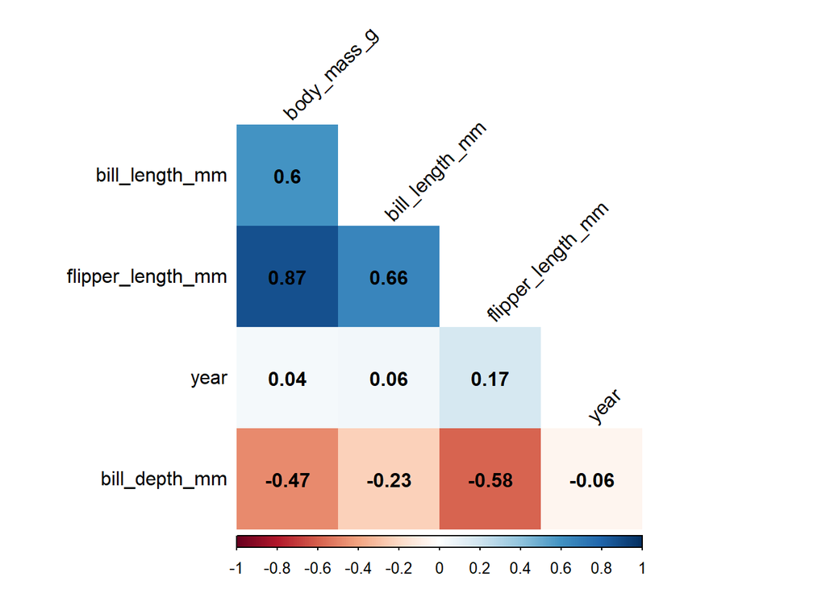

```r
corrplot(matrix_cor_tres_decimales, insig = "p-value", sig.level = 0.05,
         method = "shade", shade.col = NA,
         tl.col = "black",
         addCoef.col = "black", tl.srt = 45,
         order = "AOE", type = "lower", diag = FALSE, addshade = "all")
```

Por último, y algo más complejo, un ejemplo con el dataset de **mtcars**, y las diversas opciones de **corrplot**. Utilizando la función **cor.mtest** es posible calcular los valores de significación de las correlaciones según el nivel de confianza que le indiquemos (en este caso 0.95). Creará una columna llamada p con estos valores. Luego en corrplot es posible añadir los parámetros **p.mat** y **sig.level** para que se marquen como «tachadas» las correlaciones que no son significativas.

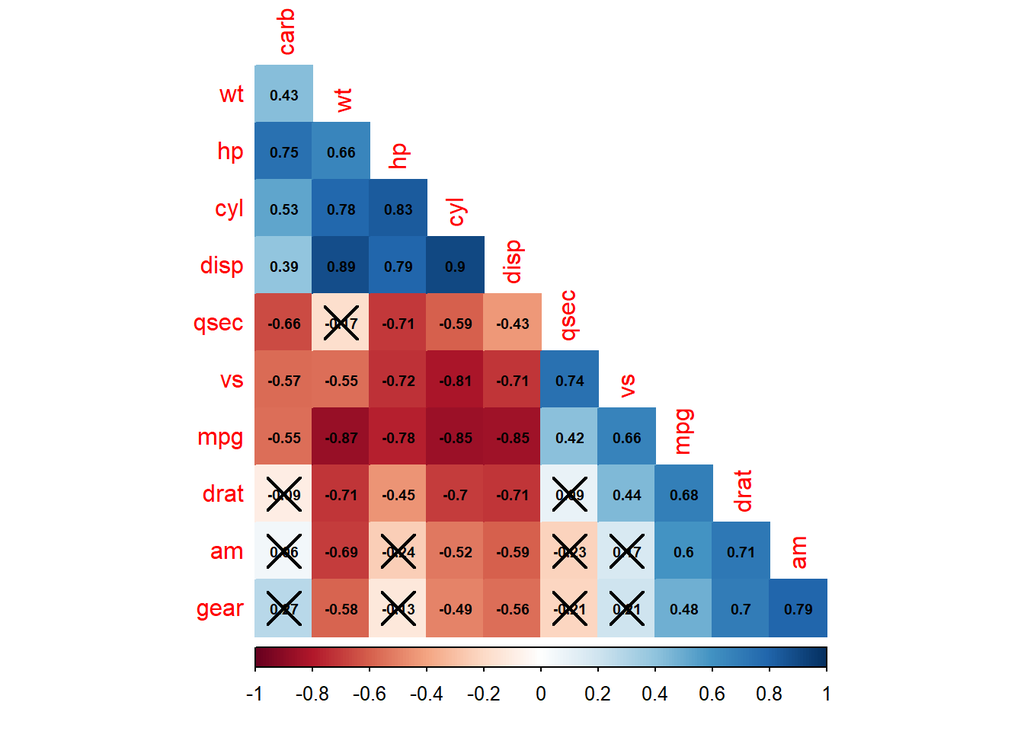

```r
data(mtcars)

mtcars.cor <- cor(mtcars)
mtcars.sig <- cor.mtest(mtcars, conf.level = 0.95)

corrplot(mtcars.cor, p.mat = mtcars.sig$p, sig.level = 0.05,
         method = "color", order = "hclust",
         type = "lower", diag = FALSE, addCoef.col = "black", number.cex = 0.6)
```

eof.